# Meta-Analytic Structural Equation Modeling

Mike Cheung

8-10 Feb 2023 (Day 2, Session 2)

# Addressing heterogeneity in MASEM

- Heterogeneity is an essential issue in meta-analysis. When there is a large amount of heterogeneity, the average becomes less important.
- We will introduce how to address heterogeneity in MASEM.

## Subgroup analysis

- When the assumption of the common correlation matrix is not tenable, we may try two alternative approaches: A subgroup analysis or a random-effects model
- Subgroup analysis: try to group studies according to the study characteristics into relatively homogeneous subgroups (Cheung & Chan, 2005; Jak & Cheung, 2018)[^1], [^2]
  - Pros: Similar to conventional meta-regression by using study characteristics as the moderators;
  - Cons: Only categorical moderators are allowed; fewer studies are in each group.

## Random-effects TSSEM

- The fixed-effects TSSEM has been extended to a random-effects model (Cheung, 2014), which is mathematically the same as the random-effects GLS proposed by Becker (1992).
- There are several pros and cons of applying a random-effects model:
  - Pros: Treating differences across studies as random effects;
  - Cons: Difficult to explain study differences by using study characteristics as the moderators.
- Stage 1 analysis:
  - Multivariate random-effects model is used to synthesize correlation matrices;
- Stage 2 analysis:
  - Similar to the fixed-effects TSSEM, we use the WLS estimation to fit structural equation models on the average correlation matrix.

### A conceptual overview of TSSEM

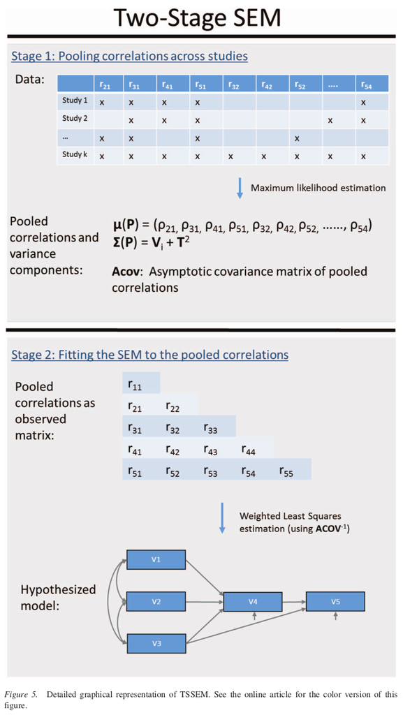

### Random-effects TSSEM: Stage 1 analysis (1)

- A multivariate meta-analysis is used to synthesize the correlation matrices
  - $\boldsymbol{r}_i = \boldsymbol{\rho}_\mathrm{R} + \boldsymbol{u}_i + \boldsymbol{e}_i$,
  - where $\mathrm{Var}(\boldsymbol{e}_i)=V_i$ is the known sampling covariance matrix and $\mathrm{Var}(\boldsymbol{u}_i)=T^2$ is the heterogeneity covariance matrix that has to be estimated.
- The SEM-based multivariate meta-analysis is used to obtain the average correlation matrix $R_\mathrm{R}$ and its asymptotic sampling covariance matrix $V_\mathrm{R}$.
- The sampling covariance matrix of the correlations can be obtained by the following R code.

```r
library(metaSEM)

## Sample correlation matrix
R <- matrix(c(1, .3, .4,
              .3, 1, .5,
              .4, .5, 1), nrow=3, ncol=3,
            dimnames = list(c("x1", "x2", "x3"), c("x1", "x2", "x3")))
R
```

```
##     x1  x2  x3
## x1 1.0 0.3 0.4
## x2 0.3 1.0 0.5
## x3 0.4 0.5 1.0
```

```r
vechs(R)
```

```
## [1] 0.3 0.4 0.5
```

```r
## Compute the sampling covariance matrix of the correlations with n=100
asyCov(R, n=100)
```

```
##          x2_x1    x3_x1    x3_x2
## x2_x1 0.008281 0.003450 0.002265
## x3_x1 0.003450 0.007056 0.001270
## x3_x2 0.002265 0.001270 0.005625
```

### Random-effects TSSEM: Stage 2 analysis

- Suppose the proposed correlation structure is $\rho_\mathrm{R}(\theta)=\mathrm{vechs}(P_\mathrm{R}(\theta))$, the discrepancy function is
  - $F_\mathrm{WLS}(\theta) = (r_\mathrm{R} - \rho_\mathrm{R}(\theta))^\mathrm{T} V_\mathrm{R}^{-1} (r_\mathrm{R} - \rho_\mathrm{R}(\theta))$
  - The model is similar to that for the fixed-effects TSSEM.
- Notes on the heterogeneity matrix ($T^2$) in stage 2 analysis:
  - $T^2$ is not directly involved in the above fit function;
  - As $V_\mathrm{R}$ is estimated after controlling for the random effects $T^2$, $V_\mathrm{R}$ has already been taken the random effects into account;
  - $V_\mathrm{R}$ is usually **larger** than $V_\mathrm{F}$. Thus, the SEs in the random-effects model are generally larger than those in the fixed-effects model.

## OSMASEM approach

- The current approaches, except the Bayesian approach, do not handle continuous moderators properly.
- Jak and Cheung (2020) proposed a one-stage MASEM approach that handles categorical and continuous moderators in MASEM.

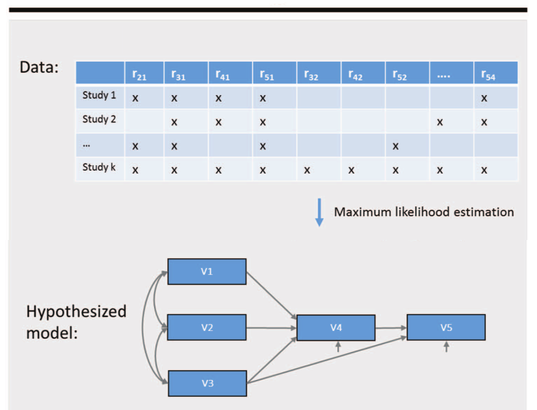

Conceptual model

## OSMASEM approach with a moderator

- Suppose we want to use `Lag` to predict the path coefficient `w2w`. The model is
  - $\beta_{w2w} = w2w + w2w_1*Lag$, where `w2w` is the path coefficient when `Lag`=0 and `w2w_1` is the change when `Lag` increases one unit.
  - $\beta_{w2s} = w2s + w2s_1*Lag$
  - $\beta_{s2w} = s2w + s2w_1*Lag$
  - $\beta_{s2s} = s2s + s2s_1*Lag$

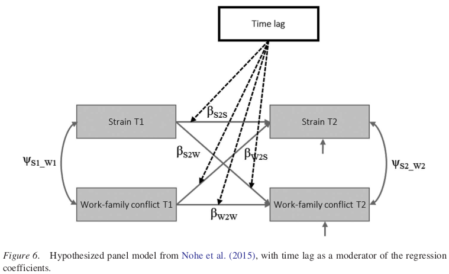

Jak and Cheung (2020)

## Correction for unreliability

- The observed correlation coefficients are usually smaller than the actual correlations without measurement error.
- We may correct the measurement error by:
  - $r_{corrected} = \frac{r_{xy}}{\sqrt{r_{xx'}{r_{yy'}}}}$, where $r_{corrected}$ is the corrected correlation, $r_{xy}$ is the observed correlation, $r_{xx'}$ and $r_{yy'}$ are the reliability coefficients of $x$ and $y$, respectively.
- There is some controversy over whether it is necessary to correct for attenuation and statistical artifacts.
  - Rosenthal (1991)[^3] criticized the use of a correction for attenuation because the corrected values are not as useful as the uncorrected values in realistic settings.
  - Other researchers (e.g., Schmidt and Hunter, 2015)[^4] argued for correcting for attenuation before combining the correlation matrices.
- MASEM:
  - Michel et al. (2011)[^5] suggested that substantive model conclusions in the psychological literature are generally unaffected by study artifacts and related statistical corrections.
  - As their conclusions are based on real examples rather than computer simulations, further research may address the effects of unreliability in MASEM.

# Examples and applications

## Example 1: A Five-Factor model

- This example illustrates how to apply MASEM to models with latent variables.
- Digman (1997)[^6] reported 14 correlation matrices among the five-factor model. He argued that the Big Five personality were not independent; these factors were loaded on two independent factors:
  - **Alpha** factor (general personality of socialization): Agreeableness (A), conscientiousness (C), and emotional stability (ES; the reverse of neuroticism)
  - **Beta** factor (personal growth): extraversion (E) and intellect (I)

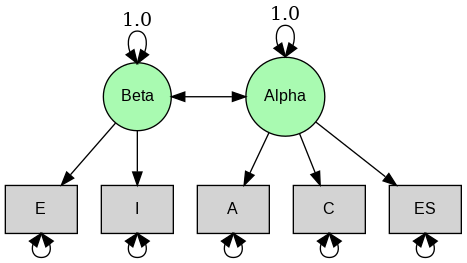

### The dataset

- The dataset is available in the `metaSEM` package as [`Digman97`](https://www.rdocumentation.org/packages/metaSEM/versions/1.3.0/topics/Digman97) (see `?Digman97` after loading the `metaSEM` package).
- To illustrate how to prepare data for MASEM, I have converted it to Excel format.
- The first sheet (`Info`) includes the study characteristics, whereas the other sheets (`Study 1` to `Study 14`) store the correlation matrices.

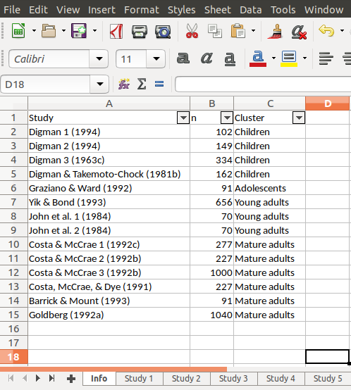

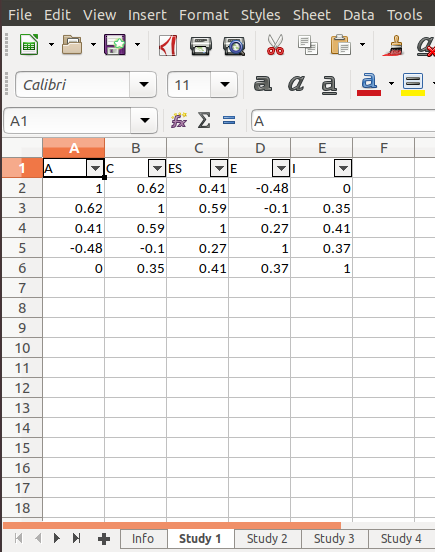

### Reading the Excel file into R

```r
## Load the library for MASEM
library(metaSEM)

## Load the library to read XLSX file
library(readxl)

## Read the study characteristics
study <- read_xlsx("Digman97.xlsx", sheet="Info")

## Display a few studies
head(study)
```

```
## # A tibble: 6 × 3
##   Study                               n Cluster
##   <chr>                           <dbl> <chr>
## 1 Digman 1 (1994)                   102 Children
## 2 Digman 2 (1994)                   149 Children
## 3 Digman 3 (1963c)                  334 Children
## 4 Digman & Takemoto-Chock (1981b)   162 Children
## 5 Graziano & Ward (1992)             91 Adolescents
## 6 Yik & Bond (1993)                 656 Young adults
```

```r
## Create an empty list to store the correlation matrices
Digman97.data <- list()

## Read Study 1 to 14 correlation matrices
for (i in 1:14) {
  ## Read each sheet and convert it into a matrix
  mat <- as.matrix(read_xlsx("Digman97.xlsx", sheet=paste0("Study ", i)))
  ## Add the row names
  rownames(mat) <- colnames(mat)
  ## Save it into a list
  Digman97.data[[i]] <- mat
}

## Add the names of the studies
names(Digman97.data) <- study$Study

## Show the first few studies
head(Digman97.data)
```

```
## $`Digman 1 (1994)`
##        A     C   ES     E    I
## A   1.00  0.62 0.41 -0.48 0.00
## C   0.62  1.00 0.59 -0.10 0.35
## ES  0.41  0.59 1.00  0.27 0.41
## E  -0.48 -0.10 0.27  1.00 0.37
## I   0.00  0.35 0.41  0.37 1.00
##
## $`Digman 2 (1994)`
##        A    C   ES     E     I
## A   1.00 0.39 0.53 -0.30 -0.05
## C   0.39 1.00 0.59  0.07  0.44
## ES  0.53 0.59 1.00  0.09  0.22
## E  -0.30 0.07 0.09  1.00  0.45
## I  -0.05 0.44 0.22  0.45  1.00
##
## $`Digman 3 (1963c)`
##       A     C   ES     E    I
## A  1.00  0.65 0.35  0.25 0.14
## C  0.65  1.00 0.37 -0.10 0.33
## ES 0.35  0.37 1.00  0.24 0.41
## E  0.25 -0.10 0.24  1.00 0.41
## I  0.14  0.33 0.41  0.41 1.00
##
## $`Digman & Takemoto-Chock (1981b)`
##        A     C   ES     E     I
## A   1.00  0.65 0.70 -0.26 -0.03
## C   0.65  1.00 0.71 -0.16  0.24
## ES  0.70  0.71 1.00  0.01  0.11
## E  -0.26 -0.16 0.01  1.00  0.66
## I  -0.03  0.24 0.11  0.66  1.00
##
## $`Graziano & Ward (1992)`
##       A    C   ES    E    I
## A  1.00 0.64 0.35 0.29 0.22
## C  0.64 1.00 0.27 0.16 0.22
## ES 0.35 0.27 1.00 0.32 0.36
## E  0.29 0.16 0.32 1.00 0.53
## I  0.22 0.22 0.36 0.53 1.00
##
## $`Yik & Bond (1993)`
##       A    C   ES    E    I
## A  1.00 0.66 0.57 0.35 0.38
## C  0.66 1.00 0.45 0.20 0.31
## ES 0.57 0.45 1.00 0.49 0.31
## E  0.35 0.20 0.49 1.00 0.59
## I  0.38 0.31 0.31 0.59 1.00
```

```r
## As we read the full correlation matrices from Excel, we want to ensure that the matrices are symmetric and positive definite.
is.pd(Digman97.data)
```

```
##                 Digman 1 (1994)                 Digman 2 (1994)
##                            TRUE                            TRUE
##                Digman 3 (1963c) Digman & Takemoto-Chock (1981b)
##                            TRUE                            TRUE
##          Graziano & Ward (1992)               Yik & Bond (1993)
##                            TRUE                            TRUE
##            John et al. 1 (1984)            John et al. 2 (1984)
##                            TRUE                            TRUE
##        Costa & McCrae 1 (1992c)        Costa & McCrae 2 (1992b)
##                            TRUE                            TRUE
##        Costa & McCrae 3 (1992b)     Costa, McCrae, & Dye (1991)
##                            TRUE                            TRUE
##          Barrick & Mount (1993)                Goldberg (1992a)
##                            TRUE                            TRUE
```

```r
## Extract the sample sizes
Digman97.n <- study$n
Digman97.n
```

```
##  [1]  102  149  334  162   91  656   70   70  277  227 1000  227   91 1040
```

```r
## Extract the cluster for subgroup analysis
Digman97.cluster <- study$Cluster
Digman97.cluster
```

```
##  [1] "Children"      "Children"      "Children"      "Children"
##  [5] "Adolescents"   "Young adults"  "Young adults"  "Young adults"
##  [9] "Mature adults" "Mature adults" "Mature adults" "Mature adults"
## [13] "Mature adults" "Mature adults"
```

```r
## Display the no. of studies
pattern.na(Digman97.data, show.na=FALSE)
```

```
##     A  C ES  E  I
## A  14 14 14 14 14
## C  14 14 14 14 14
## ES 14 14 14 14 14
## E  14 14 14 14 14
## I  14 14 14 14 14
```

```r
## Display the cumulative sample sizes
pattern.n(Digman97.data, Digman97.n)
```

```
##       A    C   ES    E    I
## A  4496 4496 4496 4496 4496
## C  4496 4496 4496 4496 4496
## ES 4496 4496 4496 4496 4496
## E  4496 4496 4496 4496 4496
## I  4496 4496 4496 4496 4496
```

### Proposed model in lavaan

- Most users find it easier to specify the models in [lavaan syntax](http://lavaan.ugent.be/tutorial/syntax1.html).
  - `f =~ x1 + x2 + x3`: the latent factor f is measured by x1, x2, and x3.
  - `y ~ x1 + x2`: y regresses on x1 and x2 or y is modeled by x1 and x2.
  - `x1 ~~ x2`: x1 and x2 are correlated.

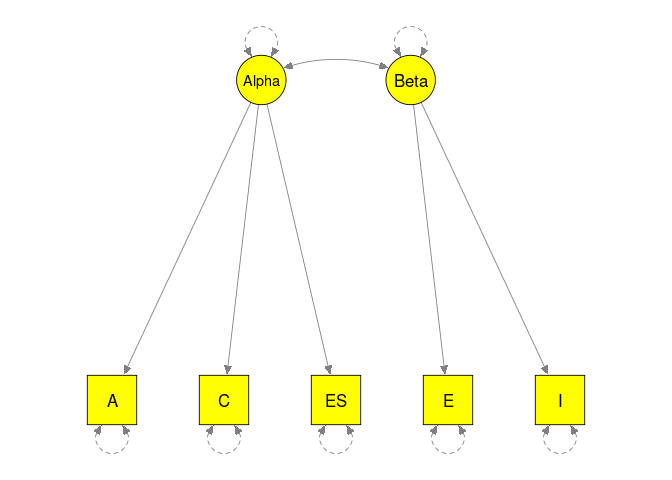

```r
## Specify the model with default labels
model1 <- "## Factor loadings
           ## Alpha is measured by A, C, and ES
           Alpha =~ A + C + ES
           ## Beta is measured by E and I
           Beta =~ E + I
           ## Factor correlation between Alpha and Beta
           Alpha ~~ Beta"

## Display the model
## See ?plot.character for the help page
plot(model1, color="yellow")
```

### Proposed model in RAM specification

- The `metaSEM` package uses the [Reticular Action Model (RAM) specification](https://www.statpower.net/Content/GCM/Handouts/Statistical%20Models%20in%20Structural%20Equation%20Modeling.pdf). We may convert the lavaan model to RAM specification with the `lavaan2RAM()` function.
- Although we do not need to specify models in RAM, it is helpful to check the RAM specification to ensure that we fit the correct model.
- An **A** matrix specifies the direct paths (single arrows) among the variables. Columns represent independent variables (IVs), whereas rows represent dependent variables (DVs).
  - The default label is **DVonIV** or **ROWonCOLUMN**.
  - $A = \left[ {\begin{array}{c|ccccccc} & A & C & ES & E& I & Alpha & Beta \\ \hline A& 0& 0& 0& 0& 0& AonAlpha& 0&\\ C& 0& 0& 0& 0& 0& ConAlpha& 0&\\ ES& 0& 0& 0& 0& 0& ESonAlpha& 0&\\ E& 0& 0& 0& 0& 0& 0& EonBeta& \\ I& 0& 0& 0& 0& 0& 0& IonBeta& \\ Alpha& 0& 0& 0& 0& 0& 0& 0& \\ Beta& 0& 0& 0& 0& 0& 0& 0& \\ \end{array} } \right]$
- An **S** matrix specifies the symmetric paths (double arrows) among the variables. The diagonals represent the variances, whereas the off-diagonals represent the covariances.
  - Since we are analyzing correlation matrices, the variances of the independent variables are fixed at 1.
  - $S = \left[ {\begin{array}{c|ccccccc} & A & C & ES & E& I & Alpha & Beta \\ \hline A& AwithA& 0& 0& 0& 0& 0& 0&\\ C& 0& CwithC& 0& 0& 0& 0& 0&\\ ES& 0& 0& ESwithES& 0& 0& 0& 0&\\ E& 0& 0& 0& EwithE& 0& 0& 0& \\ I& 0& 0& 0& 0& IwithI& 0& 0& \\ Alpha& 0& 0& 0& 0& 0& 1& 0& \\ Beta& 0& 0& 0& 0& 0& AlphawithBeta& 1& \\ \end{array} } \right]$
- An **F** matrix indicates which variables are observed.
  - Rows with the latent variables are dropped.
  - $F = \left[ {\begin{array}{c|ccccccc} & A & C & ES & E& I& Alpha & Beta \\ \hline A& 1& 0& 0& 0& 0& 0& 0&\\ C& 0& 1& 0& 0& 0& 0& 0&\\ ES& 0& 0& 1& 0& 0& 0& 0&\\ E& 0& 0& 0& 1& 0& 0& 0& \\ I& 0& 0& 0& 0& 1& 0& 0& \\ \end{array} } \right]$
- It is essential to ensure that the variables are arranged in A, C, ES, E, and I; otherwise, the variables may be incorrectly arranged.
- Values on the left-hand side of the labels are starting values. They usually do not affect the final results.

```r
## Defaults: A.notation="ON", S.notation="WITH"
RAM1 <- lavaan2RAM(model1, obs.variables=c("A","C","ES","E","I"), A.notation="on", S.notation="with")
RAM1
```

```
## $A
##       A   C   ES  E   I   Alpha           Beta
## A     "0" "0" "0" "0" "0" "0.1*AonAlpha"  "0"
## C     "0" "0" "0" "0" "0" "0.1*ConAlpha"  "0"
## ES    "0" "0" "0" "0" "0" "0.1*ESonAlpha" "0"
## E     "0" "0" "0" "0" "0" "0"             "0.1*EonBeta"
## I     "0" "0" "0" "0" "0" "0"             "0.1*IonBeta"
## Alpha "0" "0" "0" "0" "0" "0"             "0"
## Beta  "0" "0" "0" "0" "0" "0"             "0"
##
## $S
##       A            C            ES             E            I
## A     "0.5*AwithA" "0"          "0"            "0"          "0"
## C     "0"          "0.5*CwithC" "0"            "0"          "0"
## ES    "0"          "0"          "0.5*ESwithES" "0"          "0"
## E     "0"          "0"          "0"            "0.5*EwithE" "0"
## I     "0"          "0"          "0"            "0"          "0.5*IwithI"
## Alpha "0"          "0"          "0"            "0"          "0"
## Beta  "0"          "0"          "0"            "0"          "0"
##       Alpha             Beta
## A     "0"               "0"
## C     "0"               "0"
## ES    "0"               "0"
## E     "0"               "0"
## I     "0"               "0"
## Alpha "1"               "0*AlphawithBeta"
## Beta  "0*AlphawithBeta" "1"
##
## $F
##    A C ES E I Alpha Beta
## A  1 0  0 0 0     0    0
## C  0 1  0 0 0     0    0
## ES 0 0  1 0 0     0    0
## E  0 0  0 1 0     0    0
## I  0 0  0 0 1     0    0
##
## $M
##   A C ES E I Alpha Beta
## 1 0 0  0 0 0     0    0
```

- It is sometimes hard to read the default labels. We may specify our own labels.

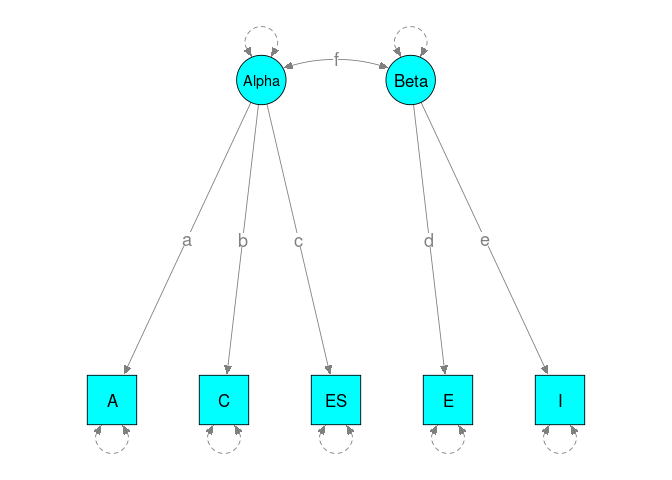

```r
## Specify the model with our own labels
model2 <- "## Alpha is measured by A, C, and ES
           Alpha =~ a*A + b*C + c*ES
           ## Beta is measured by E and I
           Beta =~ d*E + e*I
           ## Factor correlation between Alpha and Beta
           Alpha ~~ f*Beta"

## Display the model
plot(model2, color="cyan")
```

```r
RAM2 <- lavaan2RAM(model2, obs.variables=c("A","C","ES","E","I"))
RAM2
```

```
## $A
##       A   C   ES  E   I   Alpha   Beta
## A     "0" "0" "0" "0" "0" "0.1*a" "0"
## C     "0" "0" "0" "0" "0" "0.1*b" "0"
## ES    "0" "0" "0" "0" "0" "0.1*c" "0"
## E     "0" "0" "0" "0" "0" "0"     "0.1*d"
## I     "0" "0" "0" "0" "0" "0"     "0.1*e"
## Alpha "0" "0" "0" "0" "0" "0"     "0"
## Beta  "0" "0" "0" "0" "0" "0"     "0"
##
## $S
##       A            C            ES             E            I            Alpha
## A     "0.5*AWITHA" "0"          "0"            "0"          "0"          "0"
## C     "0"          "0.5*CWITHC" "0"            "0"          "0"          "0"
## ES    "0"          "0"          "0.5*ESWITHES" "0"          "0"          "0"
## E     "0"          "0"          "0"            "0.5*EWITHE" "0"          "0"
## I     "0"          "0"          "0"            "0"          "0.5*IWITHI" "0"
## Alpha "0"          "0"          "0"            "0"          "0"          "1"
## Beta  "0"          "0"          "0"            "0"          "0"          "0*f"
##       Beta
## A     "0"
## C     "0"
## ES    "0"
## E     "0"
## I     "0"
## Alpha "0*f"
## Beta  "1"
##
## $F
##    A C ES E I Alpha Beta
## A  1 0  0 0 0     0    0
## C  0 1  0 0 0     0    0
## ES 0 0  1 0 0     0    0
## E  0 0  0 1 0     0    0
## I  0 0  0 0 1     0    0
##
## $M
##   A C ES E I Alpha Beta
## 1 0 0  0 0 0     0    0
```

## Fixed-effects TSSEM

- Let’s see if the fixed-effects model fits the data.
- There are *two* fixed-effects models implemented in the `metaSEM` package.
  - The multiple-group SEM approach: `tssem1(Digman97.data, Digman97.n, method="FEM")`
  - The random-effects model by setting $T^2=0$: `tssem1(Digman97.data, Digman97.n, method="REM", RE.type="Zero")`
- Simulation studies show that the multiple-group approach works better. However, it may not work well when there are a lot of missing data.

### Stage 1 Analysis

- Before interpreting the results, we should check the `OpenMx status1` code. The optimization is okay when it is either 0 or 1.
- The test statistic on testing the homogeneity test of the correlation matrix is $\chi^2(df=130, N=4496)=1505.44, p < 0.001$.
- Both the RMSEA and SRMR are very large, indicating that the proposed model (homogeneity of correlation matrices) did not fit the data well.
- The estimates of the $S[i,j]$ represent the element of the pooled correlation (or covariance) matrix.

```r
## method="FEM": fixed-effects TSSEM
fixed1 <- tssem1(Digman97.data, Digman97.n, method="FEM")

## summary of the findings
summary(fixed1)
```

```
##
## Call:
## tssem1FEM(Cov = Cov, n = n, cor.analysis = cor.analysis, model.name = model.name,
##     cluster = cluster, suppressWarnings = suppressWarnings, silent = silent,
##     run = run)
##
## Coefficients:
##        Estimate Std.Error z value  Pr(>|z|)
## S[1,2] 0.363278  0.013368 27.1759 < 2.2e-16 ***
## S[1,3] 0.390375  0.012880 30.3076 < 2.2e-16 ***
## S[1,4] 0.103572  0.015048  6.8830 5.862e-12 ***
## S[1,5] 0.092286  0.015047  6.1331 8.621e-10 ***
## S[2,3] 0.416070  0.012519 33.2344 < 2.2e-16 ***
## S[2,4] 0.135148  0.014776  9.1464 < 2.2e-16 ***
## S[2,5] 0.141431  0.014866  9.5135 < 2.2e-16 ***
## S[3,4] 0.244459  0.014153 17.2723 < 2.2e-16 ***
## S[3,5] 0.138339  0.014834  9.3259 < 2.2e-16 ***
## S[4,5] 0.424566  0.012376 34.3070 < 2.2e-16 ***
## ---
## Signif. codes:  0 '***' 0.001 '**' 0.01 '*' 0.05 '.' 0.1 ' ' 1
##
## Goodness-of-fit indices:
##                                      Value
## Sample size                      4496.0000
## Chi-square of target model       1505.4443
## DF of target model                130.0000
## p value of target model             0.0000
## Chi-square of independence model 4471.4242
## DF of independence model          140.0000
## RMSEA                               0.1815
## RMSEA lower 95% CI                  0.1736
## RMSEA upper 95% CI                  0.1901
## SRMR                                0.1621
## TLI                                 0.6580
## CFI                                 0.6824
## AIC                              1245.4443
## BIC                               412.0217
## OpenMx status1: 0 ("0" or "1": The optimization is considered fine.
## Other values may indicate problems.)
```

```r
## extract coefficients
coef(fixed1)
```

```
##             A         C        ES         E          I
## A  1.00000000 0.3632782 0.3903748 0.1035716 0.09228557
## C  0.36327824 1.0000000 0.4160695 0.1351477 0.14143058
## ES 0.39037483 0.4160695 1.0000000 0.2444593 0.13833895
## E  0.10357155 0.1351477 0.2444593 1.0000000 0.42456626
## I  0.09228557 0.1414306 0.1383390 0.4245663 1.00000000
```

### Stage 2 Analysis

```r
fixed2 <- tssem2(fixed1, RAM=RAM1)
summary(fixed2)
```

```
##
## Call:
## wls(Cov = coef.tssem1FEM(tssem1.obj), aCov = vcov.tssem1FEM(tssem1.obj),
##     n = sum(tssem1.obj$n), RAM = RAM, Amatrix = Amatrix, Smatrix = Smatrix,
##     Fmatrix = Fmatrix, diag.constraints = diag.constraints, cor.analysis = tssem1.obj$cor.analysis,
##     intervals.type = intervals.type, mx.algebras = mx.algebras,
##     mxModel.Args = mxModel.Args, subset.variables = subset.variables,
##     model.name = model.name, suppressWarnings = suppressWarnings,
##     silent = silent, run = run)
##
## 95% confidence intervals: z statistic approximation
## Coefficients:
##               Estimate Std.Error   lbound   ubound z value  Pr(>|z|)
## AonAlpha      0.562800  0.015380 0.532655 0.592944  36.593 < 2.2e-16 ***
## ConAlpha      0.605217  0.015324 0.575183 0.635251  39.495 < 2.2e-16 ***
## EonBeta       0.781413  0.034244 0.714297 0.848529  22.819 < 2.2e-16 ***
## ESonAlpha     0.719201  0.015685 0.688458 0.749943  45.852 < 2.2e-16 ***
## IonBeta       0.551374  0.026031 0.500354 0.602394  21.181 < 2.2e-16 ***
## AlphawithBeta 0.362678  0.022384 0.318806 0.406550  16.203 < 2.2e-16 ***
## ---
## Signif. codes:  0 '***' 0.001 '**' 0.01 '*' 0.05 '.' 0.1 ' ' 1
##
## Goodness-of-fit indices:
##                                                Value
## Sample size                                4496.0000
## Chi-square of target model                   65.4526
## DF of target model                            4.0000
## p value of target model                       0.0000
## Number of constraints imposed on "Smatrix"    0.0000
## DF manually adjusted                          0.0000
## Chi-square of independence model           3112.7090
## DF of independence model                     10.0000
## RMSEA                                         0.0585
## RMSEA lower 95% CI                            0.0465
## RMSEA upper 95% CI                            0.0713
## SRMR                                          0.0284
## TLI                                           0.9505
## CFI                                           0.9802
## AIC                                          57.4526
## BIC                                          31.8088
## OpenMx status1: 0 ("0" or "1": The optimization is considered fine.
## Other values indicate problems.)
```

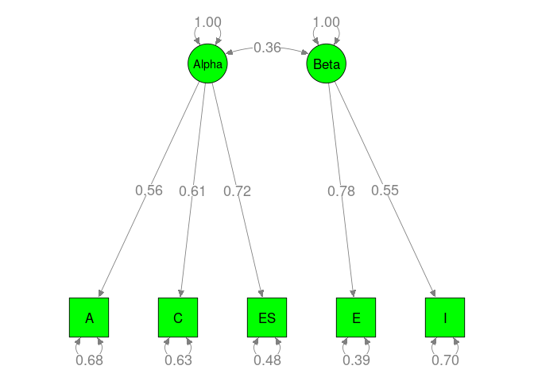

```r
plot(fixed2, color="green")
```

## Fixed-effects TSSEM with the type of participants as a moderator

### Stage 1 analysis

- As the assumption of the homogeneity of the correlation matrices has not been met, we group the studies into clusters based on the study characteristics.
- For ease of illustration, we recode the data into younger and older participants.
- From the results, splitting the data into younger and older participants does not explain the heterogeneity of the data well.

```r
# Display the original study characteristic
table(Digman97.cluster)
```

```
## Digman97.cluster
##   Adolescents      Children Mature adults  Young adults
##             1             4             6             3
```

```r
## Younger participants: "Children" and "Adolescents"
## Older participants: "Mature adults"
sample <- ifelse(Digman97.cluster %in% c("Children", "Adolescents"),
                 yes="Younger participants", no="Older participants")
table(sample)
```

```
## sample
##   Older participants Younger participants
##                    9                    5
```

```r
## cluster: variable for the analysis with cluster
fixed1.cluster <- tssem1(Digman97.data, Digman97.n, method="FEM", cluster=sample)

summary(fixed1.cluster)
```

```
## $`Older participants`
##
## Call:
## tssem1FEM(Cov = data.cluster[[i]], n = n.cluster[[i]], cor.analysis = cor.analysis,
##     model.name = model.name, suppressWarnings = suppressWarnings)
##
## Coefficients:
##        Estimate Std.Error z value  Pr(>|z|)
## S[1,2] 0.297471  0.015436 19.2716 < 2.2e-16 ***
## S[1,3] 0.370248  0.014532 25.4774 < 2.2e-16 ***
## S[1,4] 0.137694  0.016403  8.3944 < 2.2e-16 ***
## S[1,5] 0.098061  0.016724  5.8637 4.528e-09 ***
## S[2,3] 0.393692  0.014146 27.8307 < 2.2e-16 ***
## S[2,4] 0.183045  0.016055 11.4009 < 2.2e-16 ***
## S[2,5] 0.092774  0.016643  5.5743 2.485e-08 ***
## S[3,4] 0.260753  0.015554 16.7645 < 2.2e-16 ***
## S[3,5] 0.096141  0.016573  5.8009 6.596e-09 ***
## S[4,5] 0.411756  0.013900 29.6225 < 2.2e-16 ***
## ---
## Signif. codes:  0 '***' 0.001 '**' 0.01 '*' 0.05 '.' 0.1 ' ' 1
##
## Goodness-of-fit indices:
##                                      Value
## Sample size                      3658.0000
## Chi-square of target model        825.9826
## DF of target model                 80.0000
## p value of target model             0.0000
## Chi-square of independence model 3000.9731
## DF of independence model           90.0000
## RMSEA                               0.1515
## RMSEA lower 95% CI                  0.1424
## RMSEA upper 95% CI                  0.1611
## SRMR                                0.1459
## TLI                                 0.7117
## CFI                                 0.7437
## AIC                               665.9826
## BIC                               169.6088
## OpenMx status1: 0 ("0" or "1": The optimization is considered fine.
## Other values may indicate problems.)
##
```

[output cut: 24 more lines]

```
## Chi-square of target model        346.2810
## DF of target model                 40.0000
## p value of target model             0.0000
## Chi-square of independence model 1470.4511
## DF of independence model           50.0000
## RMSEA                               0.2139
## RMSEA lower 95% CI                  0.1939
## RMSEA upper 95% CI                  0.2355
## SRMR                                0.1411
## TLI                                 0.7305
## CFI                                 0.7844
## AIC                               266.2810
## BIC                                77.0402
## OpenMx status1: 0 ("0" or "1": The optimization is considered fine.
## Other values may indicate problems.)
```

### Stage 2 analysis

- As an illustration, we show how to fit the stage 2 analysis.
- `e=3.28` in the younger participants is problematic. There are several reasons. For example, there is too little data, or the model is misspecified. We should not trust the results.

```r
fixed2.cluster <- tssem2(fixed1.cluster, RAM=RAM1)
summary(fixed2.cluster)
```

```
## $`Older participants`
##
## Call:
## wls(Cov = coef.tssem1FEM(tssem1.obj), aCov = vcov.tssem1FEM(tssem1.obj),
##     n = sum(tssem1.obj$n), RAM = RAM, Amatrix = Amatrix, Smatrix = Smatrix,
##     Fmatrix = Fmatrix, diag.constraints = diag.constraints, cor.analysis = tssem1.obj$cor.analysis,
##     intervals.type = intervals.type, mx.algebras = mx.algebras,
##     mxModel.Args = mxModel.Args, subset.variables = subset.variables,
##     model.name = model.name, suppressWarnings = suppressWarnings,
##     silent = silent, run = run)
##
## 95% confidence intervals: z statistic approximation
## Coefficients:
##               Estimate Std.Error   lbound   ubound z value  Pr(>|z|)
## AonAlpha      0.512656  0.018206 0.476973 0.548340  28.158 < 2.2e-16 ***
## ConAlpha      0.549967  0.017945 0.514795 0.585140  30.647 < 2.2e-16 ***
## EonBeta       0.967136  0.058751 0.851986 1.082287  16.462 < 2.2e-16 ***
## ESonAlpha     0.732173  0.018929 0.695074 0.769273  38.680 < 2.2e-16 ***
## IonBeta       0.430649  0.029634 0.372568 0.488730  14.532 < 2.2e-16 ***
## AlphawithBeta 0.349236  0.028118 0.294125 0.404346  12.420 < 2.2e-16 ***
## ---
## Signif. codes:  0 '***' 0.001 '**' 0.01 '*' 0.05 '.' 0.1 ' ' 1
##
## Goodness-of-fit indices:
##                                                Value
## Sample size                                3658.0000
## Chi-square of target model                   21.9954
## DF of target model                            4.0000
## p value of target model                       0.0002
## Number of constraints imposed on "Smatrix"    0.0000
## DF manually adjusted                          0.0000
## Chi-square of independence model           2273.3313
## DF of independence model                     10.0000
## RMSEA                                         0.0351
## RMSEA lower 95% CI                            0.0217
## RMSEA upper 95% CI                            0.0500
## SRMR                                          0.0160
## TLI                                           0.9801
## CFI                                           0.9920
## AIC                                          13.9954
```

[output cut: 32 more lines]

```
## p value of target model                       0.0000
## Number of constraints imposed on "Smatrix"    0.0000
## DF manually adjusted                          0.0000
## Chi-square of independence model           2480.2408
## DF of independence model                     10.0000
## RMSEA                                         0.2057
## RMSEA lower 95% CI                            0.1778
## RMSEA upper 95% CI                            0.2350
## SRMR                                          0.1051
## TLI                                           0.8567
## CFI                                           0.9427
## AIC                                         137.6166
## BIC                                         118.6926
## OpenMx status1: 0 ("0" or "1": The optimization is considered fine.
## Other values indicate problems.)
```

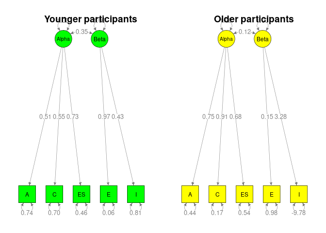

```r
## Setup two plots side-by-side
layout(t(1:2))

## Plot the first group
plot(fixed2.cluster[[1]], col="green")
title("Younger participants")

## Plot the second group
plot(fixed2.cluster[[2]], col="yellow")
title("Older participants")
```

## Random-effects TSSEM

- The subgroup analysis cannot help us to identify meaningful subgroups. A better option is to apply a random-effects model.

### Stage 1 Analysis

- There are ten correlation coefficients in the analysis with 55 elements in the variance component matrix of the random effects with `RE.type="Symm"`. The `OpenMx status1` is 5 indicating that there are estimation issues. We should not trust the results!
  - `RE.type="Symm"`: $T^2 = \left[ {\begin{array}{c|ccc} & r_{2,1} & r_{3,1} & r_{3,2}\\ \hline r_{2,1}& a& & & \\ r_{3,1}& b& d& & \\ r_{3,2}& c& e& f&\\ \end{array} } \right]$.
  - `RE.type="Diag"`: $T^2 = \left[ {\begin{array}{c|ccc} & r_{2,1} & r_{3,1} & r_{3,2}\\ \hline r_{2,1}& a& & & \\ r_{3,1}& 0& b& & \\ r_{3,2}& 0& 0& c&\\ \end{array} } \right]$.
  - `RE.type="Zero"`: $T^2 = \left[ {\begin{array}{c|ccc} & r_{2,1} & r_{3,1} & r_{3,2}\\ \hline r_{2,1}& 0& & & \\ r_{3,1}& 0& 0& & \\ r_{3,2}& 0& 0& 0&\\ \end{array} } \right]$.

```r
## Let's try to estimate all elements in the variance component matrix RE.type="Symm".
## Please note that this model is problematic as there are too many parameters.
random0 <- tssem1(Digman97.data, Digman97.n, method="REM", RE.type="Symm")
summary(random0)
```

```
##
## Call:
## meta(y = ES, v = acovR, RE.startvalues = RE.startvalues, RE.lbound = RE.lbound,
##     I2 = I2, model.name = model.name, suppressWarnings = TRUE,
##     silent = silent, run = run)
##
## 95% confidence intervals: z statistic approximation (robust=FALSE)
## Coefficients:
##                Estimate   Std.Error      lbound      ubound z value Pr(>|z|)
## Intercept1   1.0000e-01  5.2025e+02 -1.0196e+03  1.0198e+03   2e-04   0.9998
## Intercept2   1.0001e-01  6.5751e+02 -1.2886e+03  1.2888e+03   2e-04   0.9999
## Intercept3   9.9990e-02  7.4922e+02 -1.4684e+03  1.4686e+03   1e-04   0.9999
## Intercept4   9.9991e-02  1.5451e+02 -3.0274e+02  3.0294e+02   6e-04   0.9995
## Intercept5   1.0001e-01  4.8142e+02 -9.4346e+02  9.4366e+02   2e-04   0.9998
## Intercept6   9.9990e-02  7.2227e+02 -1.4155e+03  1.4157e+03   1e-04   0.9999
## Intercept7   9.9996e-02  1.0386e+03 -2.0354e+03  2.0356e+03   1e-04   0.9999
## Intercept8   1.0000e-01  5.0466e+02 -9.8901e+02  9.8921e+02   2e-04   0.9998
## Intercept9   9.9993e-02  1.1365e+03 -2.2273e+03  2.2275e+03   1e-04   0.9999
## Intercept10  1.0001e-01  3.6402e+02 -7.1336e+02  7.1356e+02   3e-04   0.9998
## Tau2_1_1     1.0034e-01          NA          NA          NA      NA       NA
## Tau2_2_1     9.9852e-02          NA          NA          NA      NA       NA
## Tau2_2_2     1.0028e-01          NA          NA          NA      NA       NA
## Tau2_3_1     9.9993e-02          NA          NA          NA      NA       NA
## Tau2_3_2     9.9747e-02          NA          NA          NA      NA       NA
## Tau2_3_3     1.0032e-01          NA          NA          NA      NA       NA
## Tau2_4_1     9.9831e-02          NA          NA          NA      NA       NA
## Tau2_4_2     9.9803e-02          NA          NA          NA      NA       NA
## Tau2_4_3     1.0006e-01          NA          NA          NA      NA       NA
## Tau2_4_4     1.0031e-01  1.3072e+04 -2.5620e+04  2.5620e+04   0e+00   1.0000
## Tau2_5_1     9.9920e-02          NA          NA          NA      NA       NA
## Tau2_5_2     9.9999e-02          NA          NA          NA      NA       NA
## Tau2_5_3     9.9441e-02          NA          NA          NA      NA       NA
## Tau2_5_4     9.9630e-02          NA          NA          NA      NA       NA
## Tau2_5_5     1.0051e-01          NA          NA          NA      NA       NA
## Tau2_6_1     9.9413e-02          NA          NA          NA      NA       NA
## Tau2_6_2     9.9725e-02          NA          NA          NA      NA       NA
## Tau2_6_3     1.0018e-01          NA          NA          NA      NA       NA
## Tau2_6_4     1.0023e-01          NA          NA          NA      NA       NA
## Tau2_6_5     1.0015e-01          NA          NA          NA      NA       NA
## Tau2_6_6     1.0045e-01          NA          NA          NA      NA       NA
```

[output cut: 44 more lines]

```
## Intercept4: I2 (Q statistic)    0.9678
## Intercept5: I2 (Q statistic)    0.9770
## Intercept6: I2 (Q statistic)    0.9686
## Intercept7: I2 (Q statistic)    0.9685
## Intercept8: I2 (Q statistic)    0.9708
## Intercept9: I2 (Q statistic)    0.9684
## Intercept10: I2 (Q statistic)   0.9774
##
## Number of studies (or clusters): 14
## Number of observed statistics: 140
## Number of estimated parameters: 65
## Degrees of freedom: 75
## -2 log likelihood: 510.6656
## OpenMx status1: 5 ("0" or "1": The optimization is considered fine.
## Other values may indicate problems.)
```

- We may specify `RE.type="Diag"` with only 10 variances in the diagonal variance component matrix.
- The minimum and the maximum $I^2$ are 0.7669 and 0.9326, respectively.
- The random-effects model is more appropriate.

```r
## method="REM": Random-effects model
random1 <- tssem1(Digman97.data, Digman97.n, method="REM", RE.type="Diag")
summary(random1)
```

```
##
## Call:
## meta(y = ES, v = acovR, RE.constraints = Diag(paste0(RE.startvalues,
##     "*Tau2_", 1:no.es, "_", 1:no.es)), RE.lbound = RE.lbound,
##     I2 = I2, model.name = model.name, suppressWarnings = TRUE,
##     silent = silent, run = run)
##
## 95% confidence intervals: z statistic approximation (robust=FALSE)
## Coefficients:
##                Estimate   Std.Error      lbound      ubound z value  Pr(>|z|)
## Intercept1   0.38971910  0.05429256  0.28330764  0.49613055  7.1781 7.068e-13
## Intercept2   0.43265879  0.04145136  0.35141562  0.51390197 10.4377 < 2.2e-16
## Intercept3   0.04945635  0.06071079 -0.06953461  0.16844731  0.8146   0.41529
## Intercept4   0.09603708  0.04478711  0.00825595  0.18381820  2.1443   0.03201
## Intercept5   0.42724243  0.03911620  0.35057609  0.50390878 10.9224 < 2.2e-16
## Intercept6   0.11929318  0.04106203  0.03881309  0.19977328  2.9052   0.00367
## Intercept7   0.19292425  0.04757962  0.09966991  0.28617859  4.0548 5.018e-05
## Intercept8   0.22690164  0.03240892  0.16338132  0.29042196  7.0012 2.538e-12
## Intercept9   0.18105567  0.04258855  0.09758364  0.26452770  4.2513 2.126e-05
## Intercept10  0.43614968  0.03205960  0.37331401  0.49898535 13.6043 < 2.2e-16
## Tau2_1_1     0.03648371  0.01513054  0.00682839  0.06613903  2.4113   0.01590
## Tau2_2_2     0.01963098  0.00859789  0.00277942  0.03648254  2.2832   0.02242
## Tau2_3_3     0.04571438  0.01952285  0.00745030  0.08397845  2.3416   0.01920
## Tau2_4_4     0.02236122  0.00995083  0.00285794  0.04186449  2.2472   0.02463
## Tau2_5_5     0.01729072  0.00796404  0.00168149  0.03289995  2.1711   0.02992
## Tau2_6_6     0.01815481  0.00895896  0.00059557  0.03571405  2.0264   0.04272
## Tau2_7_7     0.02604882  0.01130266  0.00389601  0.04820162  2.3047   0.02119
## Tau2_8_8     0.00988761  0.00513713 -0.00018098  0.01995619  1.9247   0.05426
## Tau2_9_9     0.01988244  0.00895053  0.00233973  0.03742515  2.2214   0.02633
## Tau2_10_10   0.01049222  0.00501578  0.00066148  0.02032296  2.0918   0.03645
##
## Intercept1  ***
## Intercept2  ***
## Intercept3
## Intercept4  *
## Intercept5  ***
## Intercept6  **
## Intercept7  ***
## Intercept8  ***
## Intercept9  ***
```

[output cut: 23 more lines]

```
## Intercept4: I2 (Q statistic)    0.8703
## Intercept5: I2 (Q statistic)    0.8797
## Intercept6: I2 (Q statistic)    0.8480
## Intercept7: I2 (Q statistic)    0.8887
## Intercept8: I2 (Q statistic)    0.7669
## Intercept9: I2 (Q statistic)    0.8590
## Intercept10: I2 (Q statistic)   0.8193
##
## Number of studies (or clusters): 14
## Number of observed statistics: 140
## Number of estimated parameters: 20
## Degrees of freedom: 120
## -2 log likelihood: -112.4196
## OpenMx status1: 0 ("0" or "1": The optimization is considered fine.
## Other values may indicate problems.)
```

```r
## Extract the fixed-effects estimates
(est_fixed <- coef(random1, select="fixed"))
```

```
##  Intercept1  Intercept2  Intercept3  Intercept4  Intercept5  Intercept6
##  0.38971910  0.43265879  0.04945635  0.09603708  0.42724243  0.11929318
##  Intercept7  Intercept8  Intercept9 Intercept10
##  0.19292425  0.22690164  0.18105567  0.43614968
```

```r
## It is difficult to read the above estimates.
## We may convert the estimated vector to a symmetrical matrix
## where the diagonals are fixed at 1 (for a correlation matrix)
averageR <- vec2symMat(est_fixed, diag=FALSE)
dimnames(averageR) <- list(c("A", "C", "ES", "E", "I"),
                           c("A", "C", "ES", "E", "I"))
averageR
```

```
##             A         C        ES          E          I
## A  1.00000000 0.3897191 0.4326588 0.04945635 0.09603708
## C  0.38971910 1.0000000 0.4272424 0.11929318 0.19292425
## ES 0.43265879 0.4272424 1.0000000 0.22690164 0.18105567
## E  0.04945635 0.1192932 0.2269016 1.00000000 0.43614968
## I  0.09603708 0.1929242 0.1810557 0.43614968 1.00000000
```

```r
## We may get the variance component matrix by
VarCorr(random1)
```

```
##             [,1]       [,2]       [,3]       [,4]       [,5]       [,6]
##  [1,] 0.03648371 0.00000000 0.00000000 0.00000000 0.00000000 0.00000000
##  [2,] 0.00000000 0.01963098 0.00000000 0.00000000 0.00000000 0.00000000
##  [3,] 0.00000000 0.00000000 0.04571438 0.00000000 0.00000000 0.00000000
##  [4,] 0.00000000 0.00000000 0.00000000 0.02236122 0.00000000 0.00000000
##  [5,] 0.00000000 0.00000000 0.00000000 0.00000000 0.01729072 0.00000000
##  [6,] 0.00000000 0.00000000 0.00000000 0.00000000 0.00000000 0.01815481
##  [7,] 0.00000000 0.00000000 0.00000000 0.00000000 0.00000000 0.00000000
##  [8,] 0.00000000 0.00000000 0.00000000 0.00000000 0.00000000 0.00000000
##  [9,] 0.00000000 0.00000000 0.00000000 0.00000000 0.00000000 0.00000000
## [10,] 0.00000000 0.00000000 0.00000000 0.00000000 0.00000000 0.00000000
##             [,7]        [,8]       [,9]      [,10]
##  [1,] 0.00000000 0.000000000 0.00000000 0.00000000
##  [2,] 0.00000000 0.000000000 0.00000000 0.00000000
##  [3,] 0.00000000 0.000000000 0.00000000 0.00000000
##  [4,] 0.00000000 0.000000000 0.00000000 0.00000000
##  [5,] 0.00000000 0.000000000 0.00000000 0.00000000
##  [6,] 0.00000000 0.000000000 0.00000000 0.00000000
##  [7,] 0.02604882 0.000000000 0.00000000 0.00000000
##  [8,] 0.00000000 0.009887609 0.00000000 0.00000000
##  [9,] 0.00000000 0.000000000 0.01988244 0.00000000
## [10,] 0.00000000 0.000000000 0.00000000 0.01049222
```

### Stage 2 Analysis

- The stage 2 analysis is similar to that of the fixed-effects model.
- We may trust the results based on the random-effects model.
- The proposed model fits the data well with $\chi^2(df=4, N=4496)=7.82, p=0.0984$, CFI=$0.9922$, RMSEA=$0.0146$, and SRMR=$0.0436$.
- The estimated correlation between the two factors (labeled `AlphawithBeta` in the printout) is $0.3777$.

```r
random2 <- tssem2(random1, RAM=RAM1)
summary(random2)
```

```
##
## Call:
## wls(Cov = pooledS, aCov = aCov, n = tssem1.obj$total.n, RAM = RAM,
##     Amatrix = Amatrix, Smatrix = Smatrix, Fmatrix = Fmatrix,
##     diag.constraints = diag.constraints, cor.analysis = cor.analysis,
##     intervals.type = intervals.type, mx.algebras = mx.algebras,
##     mxModel.Args = mxModel.Args, subset.variables = subset.variables,
##     model.name = model.name, suppressWarnings = suppressWarnings,
##     silent = silent, run = run)
##
## 95% confidence intervals: z statistic approximation
## Coefficients:
##               Estimate Std.Error   lbound   ubound z value  Pr(>|z|)
## AonAlpha      0.569435  0.052425 0.466684 0.672187 10.8619 < 2.2e-16 ***
## ConAlpha      0.590630  0.052649 0.487439 0.693821 11.2182 < 2.2e-16 ***
## EonBeta       0.679955  0.075723 0.531541 0.828370  8.9795 < 2.2e-16 ***
## ESonAlpha     0.760455  0.061963 0.639009 0.881901 12.2726 < 2.2e-16 ***
## IonBeta       0.641842  0.072459 0.499825 0.783859  8.8580 < 2.2e-16 ***
## AlphawithBeta 0.377691  0.047402 0.284785 0.470596  7.9679 1.554e-15 ***
## ---
## Signif. codes:  0 '***' 0.001 '**' 0.01 '*' 0.05 '.' 0.1 ' ' 1
##
## Goodness-of-fit indices:
##                                                Value
## Sample size                                4496.0000
## Chi-square of target model                    7.8204
## DF of target model                            4.0000
## p value of target model                       0.0984
## Number of constraints imposed on "Smatrix"    0.0000
## DF manually adjusted                          0.0000
## Chi-square of independence model            501.6768
## DF of independence model                     10.0000
## RMSEA                                         0.0146
## RMSEA lower 95% CI                            0.0000
## RMSEA upper 95% CI                            0.0297
## SRMR                                          0.0436
## TLI                                           0.9806
## CFI                                           0.9922
## AIC                                          -0.1796
## BIC                                         -25.8234
## OpenMx status1: 0 ("0" or "1": The optimization is considered fine.
## Other values indicate problems.)
```

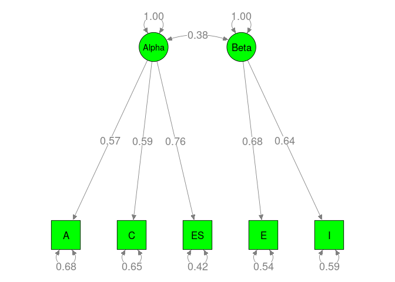

```r
## Plot the parameter estimates
plot(random2, color="green")
```

[^1]: Cheung, M. W.-L., & Chan, W. (2005). Classifying correlation matrices into relatively homogeneous subgroups: A cluster analytic approach. *Educational and Psychological Measurement*, *65*(6), 954–979. https://doi.org/10.1177/0013164404273946
[^2]: Jak, S., & Cheung, M. W.-L. (2018). Testing moderator hypotheses in meta-analytic structural equation modeling using subgroup analysis. *Behavior Research Methods*, *50*(4), 1359–1373. https://doi.org/10.3758/s13428-018-1046-3
[^3]: Rosenthal, R. (1991). *Meta-analytic procedures for social research* (Revised). Newbury Park, [Calif.]: Sage.
[^4]: Schmidt, F. L., & Hunter, J. E. (2015). *Methods of meta-analysis: Correcting error and bias in research findings* (3rd ed.). Thousand Oaks, CA: Sage.
[^5]: Michel, J. S., Viswesvaran, C., & Thomas, J. (2011). Conclusions from meta-analytic structural equation models generally do not change due to corrections for study artifacts. *Research Synthesis Methods*, *2*(3), 174-187. http://doi.org/10.1002/jrsm.47
[^6]: Digman, J. M. (1997). Higher-order factors of the Big Five. *Journal of Personality and Social Psychology*, *73*(6), 1246-1256. http://doi.org/10.1037/0022-3514.73.6.1246